# Survival and Regression Analysis of TCGA Cohort Metadata

Tani Peddagammalla

## Background

This analysis uses patient metadata I retrieved from the NIH/NCI Genomic Data Commons REST API during my MSc research project. The original project used the imaging and report data; this analysis uses the clinical fields that came with it, which include vital status, time to death and time to last follow-up across 32 TCGA project cohorts.

The aim is to model overall survival and to check whether the relationships behave the way established oncology prognostic factors would predict. I am treating the data as observational, because it is: these are not trial arms and there is no randomised comparison here.

```r
library(readr)
library(dplyr)
library(stringr)
library(ggplot2)
library(survival)
library(survminer)
library(broom)

set.seed(42)
```

```r
# Created by fetch_metadata.py from the GDC API (see README.md).
metadata_path <- "data/metadata.csv"
```

## Loading and cleaning

GDC uses several different tokens for missing values, so they are all declared up front rather than cleaned up later.

```r
raw <- read_csv(
  metadata_path,
  na = c("", "NA", "'--", "--", "not reported", "Not Reported",
         "unknown", "Unknown", "Not Allowed To Collect")
)

nrow(raw)
```

```
## [1] 7690
```

```r
n_distinct(raw$case_id)
```

```
## [1] 7690
```

The dataset is indexed by slide, and a patient can in principle contribute more than one slide. Survival is a patient-level question, so analysing at slide level would silently weight patients by how many slides they happen to have. I checked rather than assumed: in this extract the two counts are equal, so the deduplication below is a no-op. I have left it in because the file is keyed by slide and the one-to-one relationship is a property of this particular extract rather than something the schema guarantees.

```r
cases <- raw %>%
  arrange(case_id, slide_id) %>%
  distinct(case_id, .keep_all = TRUE)

nrow(cases)
```

```
## [1] 7690
```

## Constructing the survival object

Follow-up time comes from two different columns depending on whether the patient died during follow-up. Patients still alive at last contact are right-censored.

```r
dat <- cases %>%
  mutate(
    event = case_when(
      vital_status == "Dead"  ~ 1L,
      vital_status == "Alive" ~ 0L,
      TRUE ~ NA_integer_
    ),
    time_days = if_else(event == 1L,
                        as.numeric(days_to_death),
                        as.numeric(days_to_last_follow_up)),
    time_months = time_days / 30.44,

    # AJCC stage arrives as "Stage IIIA", "Stage IV" and similar.
    # Order matters here: case_when short-circuits, so IV is tested
    # before III, which is tested before II, before I.
    stage = case_when(
      str_detect(ajcc_pathologic_stage, "IV")  ~ "IV",
      str_detect(ajcc_pathologic_stage, "III") ~ "III",
      str_detect(ajcc_pathologic_stage, "II")  ~ "II",
      str_detect(ajcc_pathologic_stage, "I")   ~ "I",
      TRUE ~ NA_character_
    ),
    stage   = factor(stage, levels = c("I", "II", "III", "IV")),
    sex     = factor(gender),
    age     = as.numeric(age_at_index),
    cohort  = factor(project_id)
  ) %>%
  filter(!is.na(event), !is.na(time_days), time_days > 0)

nrow(dat)
```

```
## [1] 6864
```

```r
table(dat$event)
```

```
##
##    0    1
## 4817 2047
```

Cases with non-positive follow-up time are dropped. A recorded survival time of zero or less is a data quality artefact rather than an instantaneous death, and `Surv()` will not accept it.

```r
dat %>%
  group_by(cohort) %>%
  summarise(
    n       = n(),
    deaths  = sum(event),
    staged  = sum(!is.na(stage)),
    median_followup_months = round(median(time_months), 1),
    .groups = "drop"
  ) %>%
  arrange(desc(n))
```

```
## # A tibble: 32 × 5
##    cohort        n deaths staged median_followup_months
##    <fct>     <int>  <int>  <int>                  <dbl>
##  1 TCGA-BRCA   863    134    811                   32
##  2 TCGA-KIRC   451    168    404                   36.8
##  3 TCGA-THCA   438     16    433                   31.2
##  4 TCGA-UCEC   423     76      0                   29.1
##  5 TCGA-LUSC   412    182    354                   22
##  6 TCGA-HNSC   392    200    304                   20.6
##  7 TCGA-LUAD   369    145    314                   21.6
##  8 TCGA-PRAD   339      7      0                   32.7
##  9 TCGA-COAD   335     72    302                   22
## 10 TCGA-LGG    311     90      0                   19.7
## # ℹ 22 more rows
```

### Staging is missing by design, not at random

The `staged` column is worth pausing on. Roughly a third of the analysis set has no AJCC stage, and the missingness is not spread evenly: entire cohorts have none at all. That is not a data quality problem, it is a clinical one. AJCC staging does not apply to several of these tumour types. Brain tumours (LGG, GBM) are graded by WHO criteria rather than staged by TNM; gynaecological cancers such as UCEC, OV and CESC are conventionally staged by FIGO; prostate cancer in this release carries its own staging fields.

This matters because every model below that includes stage silently excludes those cohorts. That drops the sample from 6,864 patients to 4,346 and removes whole tumour types from the analysis rather than a random subset of patients. Reporting the stage-adjusted hazard ratios without saying so would overstate what the model covers, so the restricted sample is stated alongside each result.

## Kaplan-Meier estimates

```r
fit_overall <- survfit(Surv(time_months, event) ~ 1, data = dat)
fit_overall
```

```
## Call: survfit(formula = Surv(time_months, event) ~ 1, data = dat)
##
##         n events median 0.95LCL 0.95UCL
## [1,] 6864   2047   88.1    82.8    96.7
```

Stratifying by AJCC stage. If the data behave sensibly, the curves should separate in stage order, with Stage IV the worst.

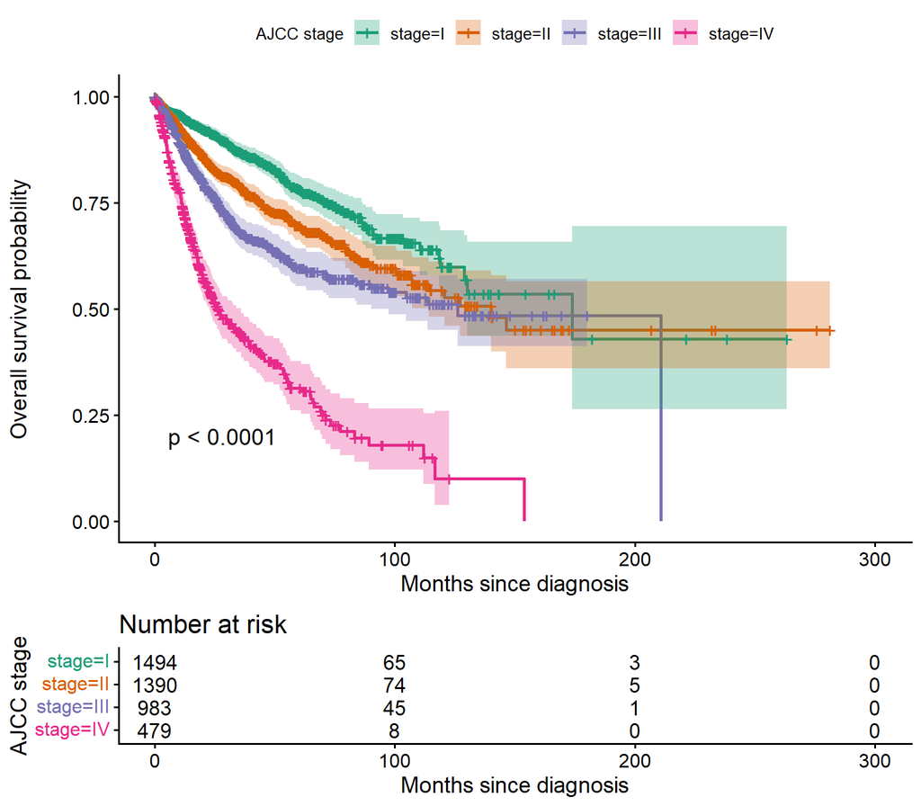

```r
stage_dat <- dat %>% filter(!is.na(stage))

fit_stage <- survfit(Surv(time_months, event) ~ stage, data = stage_dat)

ggsurvplot(
  fit_stage,
  data        = stage_dat,
  pval        = TRUE,
  conf.int    = TRUE,
  risk.table  = TRUE,
  xlab        = "Months since diagnosis",
  ylab        = "Overall survival probability",
  legend.title = "AJCC stage",
  palette     = "Dark2"
)
```

Median survival with confidence intervals, read off the same fit:

```r
round(
  summary(fit_stage)$table[, c("records", "events", "median", "0.95LCL", "0.95UCL")],
  1
)
```

```
##           records events median 0.95LCL 0.95UCL
## stage=I      1494    215  173.7   129.0      NA
## stage=II     1390    299  140.2   114.1      NA
## stage=III     983    278  126.1    90.0      NA
## stage=IV      479    261   26.5    22.8    35.9
```

The ordering is monotonic in stage, and the gap between Stage III and Stage IV is far larger than any other adjacent pair, which is what the hazard ratios below also show.

The upper confidence limit is `NA` for Stages I, II and III. That is not a failure of the computation: the survival curve for those groups never drops far enough below 0.5 within the observed follow-up for an upper bound on the median to be estimated. The median itself is identified, but how much longer it could plausibly be is not, and quoting the point estimate without that caveat would imply more precision than the data support.

```r
survdiff(Surv(time_months, event) ~ stage, data = stage_dat)
```

```
## Call:
## survdiff(formula = Surv(time_months, event) ~ stage, data = stage_dat)
##
##              N Observed Expected (O-E)^2/E (O-E)^2/V
## stage=I   1494      215    387.0     76.43     121.0
## stage=II  1390      299    345.7      6.30       9.4
## stage=III  983      278    231.0      9.55      12.2
## stage=IV   479      261     89.3    330.09     362.4
##
##  Chisq= 424  on 3 degrees of freedom, p= <2e-16
```

The log-rank test asks whether the survival distributions differ across stage groups. It tells us the curves are not the same; it does not tell us by how much, or in which direction, which is what the Cox model below is for.

## Cox proportional hazards model

```r
cox_dat <- stage_dat %>%
  filter(!is.na(age), !is.na(sex)) %>%
  mutate(cohort = droplevels(cohort))

cox_fit <- coxph(
  Surv(time_months, event) ~ age + sex + stage + strata(cohort),
  data = cox_dat
)

summary(cox_fit)
```

```
## Call:
## coxph(formula = Surv(time_months, event) ~ age + sex + stage +
##     strata(cohort), data = cox_dat)
##
##   n= 4332, number of events= 1053
##
##               coef exp(coef)  se(coef)      z Pr(>|z|)
## age       0.035353  1.035985  0.003064 11.539  < 2e-16 ***
## sexmale  -0.061349  0.940495  0.069005 -0.889    0.374
## stageII   0.383088  1.466808  0.096692  3.962 7.43e-05 ***
## stageIII  0.775262  2.171161  0.097947  7.915 2.47e-15 ***
## stageIV   1.714937  5.556327  0.110636 15.501  < 2e-16 ***
## ---
## Signif. codes:  0 '***' 0.001 '**' 0.01 '*' 0.05 '.' 0.1 ' ' 1
##
##          exp(coef) exp(-coef) lower .95 upper .95
## age         1.0360     0.9653    1.0298     1.042
## sexmale     0.9405     1.0633    0.8215     1.077
## stageII     1.4668     0.6818    1.2136     1.773
## stageIII    2.1712     0.4606    1.7919     2.631
## stageIV     5.5563     0.1800    4.4732     6.902
##
## Concordance= 0.684  (se = 0.011 )
## Likelihood ratio test= 368.5  on 5 df,   p=<2e-16
## Wald test            = 373.1  on 5 df,   p=<2e-16
## Score (logrank) test = 390.9  on 5 df,   p=<2e-16
```

I stratify by cohort rather than adjusting for it. Different tumour types have very different baseline hazards, and stratification lets each cohort keep its own baseline while still estimating a shared effect for age, sex and stage. Treating cohort as an ordinary covariate would force a single baseline hazard onto all 22 cohorts in the model, which is not a defensible assumption.

```r
tidy(cox_fit, exponentiate = TRUE, conf.int = TRUE) %>%
  mutate(across(where(is.numeric), ~ round(.x, 3)))
```

```
## # A tibble: 5 × 7
##   term     estimate std.error statistic p.value conf.low conf.high
##   <chr>       <dbl>     <dbl>     <dbl>   <dbl>    <dbl>     <dbl>
## 1 age          1.04     0.003    11.5     0        1.03       1.04
## 2 sexmale      0.94     0.069    -0.889   0.374    0.822      1.08
## 3 stageII      1.47     0.097     3.96    0        1.21       1.77
## 4 stageIII     2.17     0.098     7.92    0        1.79       2.63
## 5 stageIV      5.56     0.111    15.5     0        4.47       6.90
```

Coefficients are exponentiated, so they read as hazard ratios. A hazard ratio above 1 means a higher instantaneous risk of death relative to the reference level, which is Stage I for stage and the first factor level for sex.

### Checking the proportional hazards assumption

The Cox model assumes hazard ratios are constant over time. That assumption is testable and is worth testing rather than asserting.

```r
ph_test <- cox.zph(cox_fit)
ph_test
```

```
##        chisq df    p
## age    0.559  1 0.45
## sex    0.520  1 0.47
## stage  5.864  3 0.12
## GLOBAL 6.579  5 0.25
```

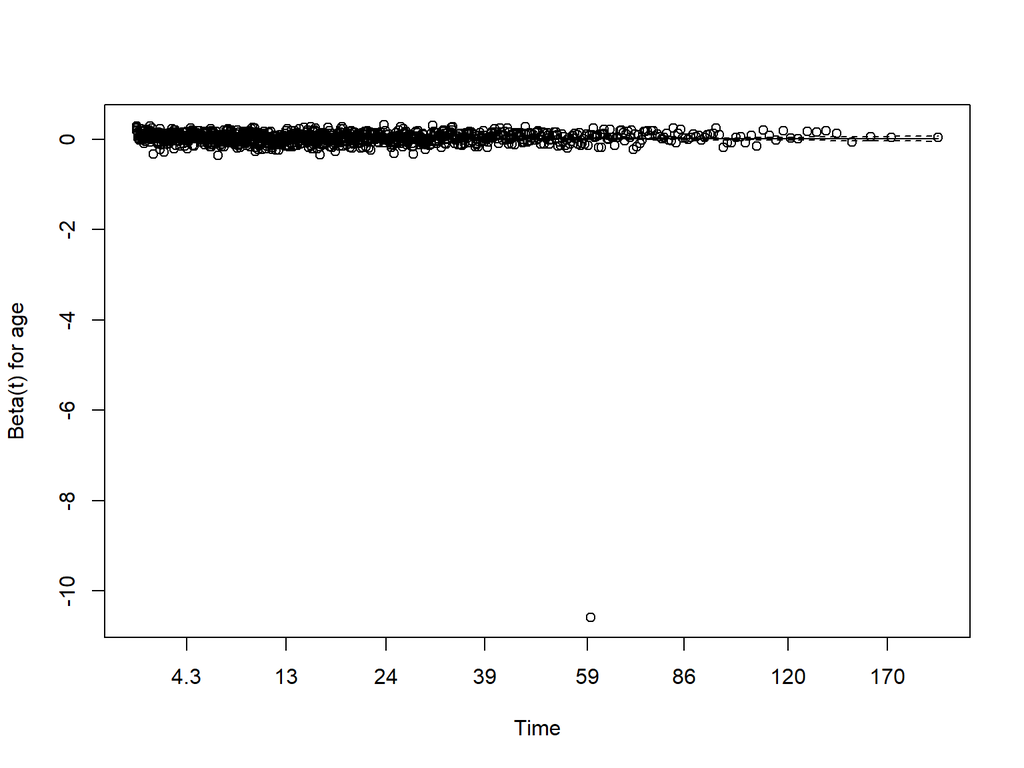

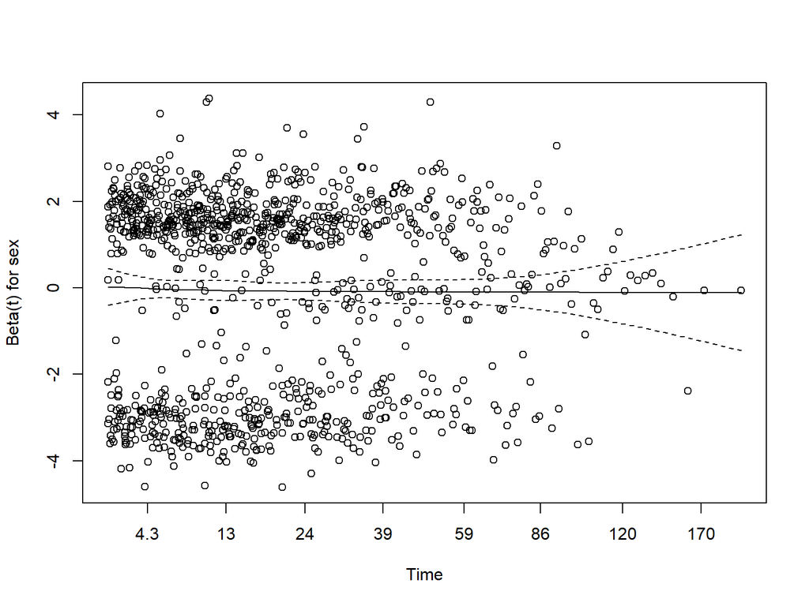

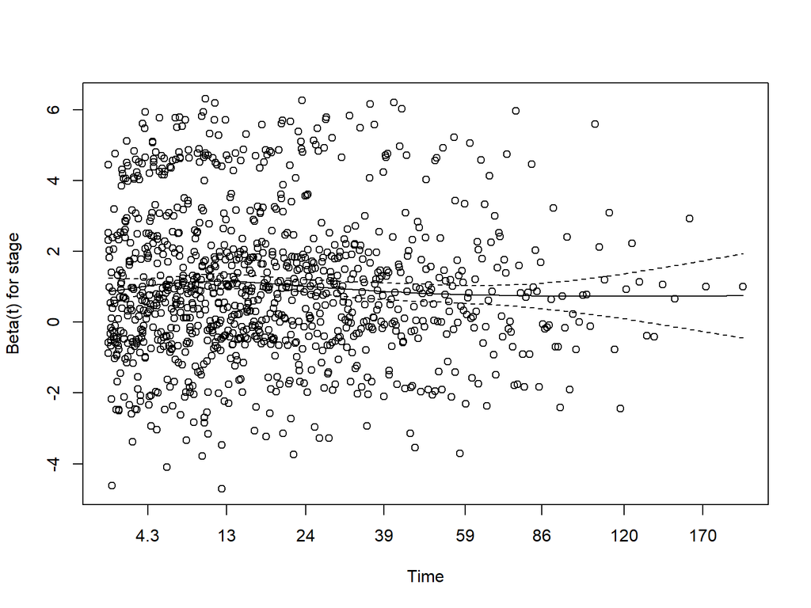

```r
plot(ph_test)
```

A small p-value for a term means its effect varies with time, in which case the single hazard ratio reported above is an average over the follow-up period and should not be quoted as if it were constant. The global test covers the model as a whole.

## Logistic regression

A separate question, and a binary rather than time-to-event one: can we predict whether a patient presented at an advanced stage from demographic information alone?

```r
log_dat <- cox_dat %>%
  mutate(advanced = as.integer(stage %in% c("III", "IV")))

logit_fit <- glm(advanced ~ age + sex, data = log_dat, family = binomial)

tidy(logit_fit, exponentiate = TRUE, conf.int = TRUE) %>%
  mutate(across(where(is.numeric), ~ round(.x, 3)))
```

```
## # A tibble: 3 × 7
##   term        estimate std.error statistic p.value conf.low conf.high
##   <chr>          <dbl>     <dbl>     <dbl>   <dbl>    <dbl>     <dbl>
## 1 (Intercept)    0.226     0.151     -9.84       0    0.167     0.303
## 2 age            1.01      0.002      4.46       0    1.01      1.01
## 3 sexmale        1.39      0.065      5.13       0    1.23      1.58
```

```r
log_dat$pred <- predict(logit_fit, type = "response")

# Calibration: observed rate within deciles of predicted risk.
log_dat %>%
  mutate(decile = ntile(pred, 10)) %>%
  group_by(decile) %>%
  summarise(
    mean_predicted = round(mean(pred), 3),
    observed_rate  = round(mean(advanced), 3),
    n = n(),
    .groups = "drop"
  )
```

```
## # A tibble: 10 × 4
##    decile mean_predicted observed_rate     n
##     <int>          <dbl>         <dbl> <int>
##  1      1          0.253         0.214   434
##  2      2          0.28          0.348   434
##  3      3          0.298         0.298   433
##  4      4          0.313         0.266   433
##  5      5          0.328         0.309   433
##  6      6          0.344         0.36    433
##  7      7          0.362         0.395   433
##  8      8          0.379         0.434   433
##  9      9          0.396         0.39    433
## 10     10          0.418         0.356   433
```

I check calibration rather than only discrimination because a model can rank patients well and still produce probabilities that are systematically wrong. If the mean predicted risk in each decile does not track the observed rate, the model is miscalibrated even if it separates cases adequately.

Here the result is negative, and worth reporting as such. Both coefficients reach significance, but predicted risk spans only about 0.25 to 0.42 across the whole cohort, and the observed rate does not increase monotonically across deciles: the top decile sits below the eighth. Age and sex carry a real but very weak signal for stage at presentation, and a model built on them alone is not usable for anything. That is a sensible clinical finding rather than a disappointing one, since stage at diagnosis depends on tumour biology, screening access and time to presentation rather than on demographics. It is also a reminder that statistical significance and practical usefulness are different questions: with roughly four thousand patients, a trivial effect will clear p < 0.001 comfortably.

## Limitations

Worth stating explicitly, since these constrain what the results above can support:

- This is observational data from a tissue repository, not a clinical trial. There is no randomisation and no controlled comparison, so none of the estimates here are causal.
- Treatment information in these fields is sparse, so the models are unadjusted for therapy, which is a substantial confounder for survival.
- Follow-up duration varies considerably between cohorts, and cohorts with short follow-up contribute few events.
- Stage was collapsed from the AJCC sub-stages, which discards information within each stage group.
- Deduplication to one row per case keeps the first slide per patient. The clinical fields are patient-level so this does not bias the clinical data, but it is an arbitrary choice worth recording.